# starbility: plot coefficient stability under combinations of controls

A common exercise in applied microeconomics is assessing the stability of a coefficient under different choices of controls. This can be a tedious task for the econometrician, particularly with a large set of controls, but more importantly, it’s difficult to concisely convey this information to the reader. Regression tables are useful for displaying a limited number of models, but they’re less useful for displaying how coefficients evolve under dozens or even hundreds of sets of controls. `starbility` provides a simple interface to create a “coefficient stability plot”, allowing both the econometrician and the reader to assess coefficient stability under different combinations of controls. `starbility` builds upon `lfe` and `ggplot2`, allowing for fast estimation of models with many groups of fixed effects and flexible plotting.

## Setup

We will use the `diamonds` dataset included in `ggplot2` as an example.

```r
library(tidyverse)
library(starbility)
library(lfe)
data("diamonds")
set.seed(43)
indices = sample(1:nrow(diamonds), replace = F, size = round(nrow(diamonds)/20))
diamonds = diamonds[indices,]
```

Suppose we are interested in understanding the relationship between the carat of a diamond and the price. We begin with a simple OLS regression.

```r
felm(price~carat, data = diamonds) %>% summary
```

```
#>
#> Call:
#>    felm(formula = price ~ carat, data = diamonds)
#>
#> Residuals:
#>      Min       1Q   Median       3Q      Max
#> -10826.6   -830.2    -15.7    528.0  11884.7
#>
#> Coefficients:
#>             Estimate Std. Error t value Pr(>|t|)
#> (Intercept) -2236.04      58.62  -38.15   <2e-16 ***
#> carat        7710.05      62.33  123.69   <2e-16 ***
#> ---
#> Signif. codes:  0 '***' 0.001 '**' 0.01 '*' 0.05 '.' 0.1 ' ' 1
#>
#> Residual standard error: 1549 on 2695 degrees of freedom
#> Multiple R-squared(full model): 0.8502   Adjusted R-squared: 0.8502
#> Multiple R-squared(proj model): 0.8502   Adjusted R-squared: 0.8502
#> F-statistic(full model):1.53e+04 on 1 and 2695 DF, p-value: < 2.2e-16
#> F-statistic(proj model): 1.53e+04 on 1 and 2695 DF, p-value: < 2.2e-16
```

We might want to control for other characteristics of the diamond and include some fixed effects:

```r
felm(price~carat+depth+table+x+y+z|cut+color+clarity, data = diamonds) %>% summary
```

```
#>
#> Call:
#>    felm(formula = price ~ carat + depth + table + x + y + z | cut +      color + clarity, data = diamonds)
#>
#> Residuals:
#>      Min       1Q   Median       3Q      Max
#> -11829.9   -581.5   -177.3    348.2  10152.4
#>
#> Coefficients:
#>       Estimate Std. Error t value Pr(>|t|)
#> carat 11398.09     230.75  49.396  < 2e-16 ***
#> depth   -47.25      22.26  -2.123   0.0338 *
#> table   -25.51      13.02  -1.959   0.0502 .
#> x     -2131.72     456.26  -4.672 3.13e-06 ***
#> y      1142.75     455.25   2.510   0.0121 *
#> z      -191.89     181.05  -1.060   0.2893
#> ---
#> Signif. codes:  0 '***' 0.001 '**' 0.01 '*' 0.05 '.' 0.1 ' ' 1
#>
#> Residual standard error: 1140 on 2673 degrees of freedom
#> Multiple R-squared(full model): 0.9195   Adjusted R-squared: 0.9188
#> Multiple R-squared(proj model): 0.9125   Adjusted R-squared: 0.9118
#> F-statistic(full model): 1328 on 23 and 2673 DF, p-value: < 2.2e-16
#> F-statistic(proj model):  4646 on 6 and 2673 DF, p-value: < 2.2e-16
#> *** Standard errors may be too high due to more than 2 groups and exactDOF=FALSE
```

The estimated coefficient of interest (`carat`) has changed substantially. Let’s use `starbility` to evaluate how the coefficient is affected by different combinations of controls.

## A first plot

Let’s begin with a simple plot, varying just two controls:

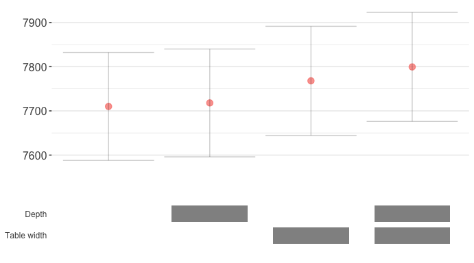

```r
perm_controls = c(
  'Depth' = 'depth',
  'Table width' = 'table'
)

stability_plot(data = diamonds,
                      lhs = 'price',
                      rhs = 'carat',
                      perm = perm_controls)
```

The first column displays the coefficient estimate and associated 95% confidence interval if we do not control for `depth` or `table`, the second column displays the estimate and CI if we control for `depth` but not `table`, etc.

## Adding controls

Now, let’s also control for the dimension of the diamond: `x`, `y`, and `z`. We probably don’t want to vary all of these three dimensions separately, so let’s include them in a single *variable set* by specifying them together, separated by `+` signs:

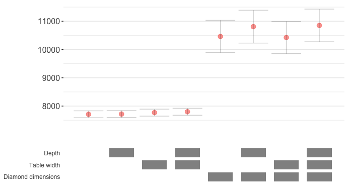

```r
perm_controls = c(
  'Depth' = 'depth',
  'Table width' = 'table',
  'Diamond dimensions' = 'x + y + z'
)

stability_plot(data = diamonds,
                      lhs = 'price',
                      rhs = 'carat',
                      perm = perm_controls)
```

Including dimensions seems to make a big difference, so perhaps we want to control for dimensions in all specifications. We can do this by specifying dimensions as `base` controls rather than `perm` controls:

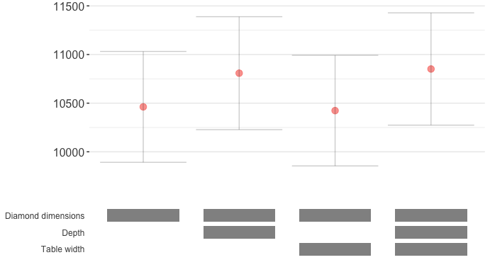

```r
base_controls = c(
  'Diamond dimensions' = 'x + y + z'
)
perm_controls = c(
  'Depth' = 'depth',
  'Table width' = 'table'
)

stability_plot(data = diamonds,
                      lhs = 'price',
                      rhs = 'carat',
                      perm = perm_controls,
                      base = base_controls)
```

## Adding fixed effects

Now, let’s add in some fixed effects. We could specify these directly in `perm`. However, explicitly declaring fixed effects by specifying them in `perm_fe` has a big advantage: it allows us to use `felm`’s implementation of the Method of Alternating Projections to sweep out fixed effects from the normal equations before estimation, resulting in a considerable performance improvement on large datasets with many sets of fixed effects. In the example below, I also increase the default value of `rel_height` to give the bottom panel a little more space:

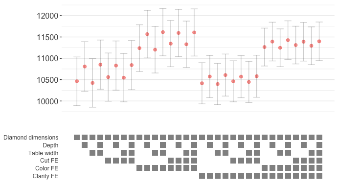

```r
perm_fe_controls = c(
  'Cut FE' = 'cut',
  'Color FE' = 'color',
  'Clarity FE' = 'clarity'
)

stability_plot(data = diamonds,
                      lhs = 'price',
                      rhs = 'carat',
                      perm = perm_controls,
                      base = base_controls,
                      perm_fe = perm_fe_controls,
                      rel_height = 0.6)
```

Note that all combinations of `perm_fe` are included, just as all combinations of `perm` are included. This is desirable in some cases, but not in others. For example, in a setting where we want to show some models with state fixed effects and some models with county fixed effects, it would never make sense to show a model with both state and county fixed effects (indeed, we would be unable to estimate such a model). We can tell `starbility` to include fixed effects *sequentially* using `nonperm_fe`. To illustrate, we will create a new fixed effect, `high_clarity`, which is collinear with `clarity` in the same way that county would be collinear with state.

[figure not shown]

```r
diamonds$high_clarity = diamonds$clarity %in% c('VS1','VVS2','VVS1','IF')

perm_fe_controls = c(
  'Cut FE' = 'cut',
  'Color FE' = 'color'
)
nonperm_fe_controls = c(
  'Clarity FE (granular)' = 'clarity',
  'Clarity FE (binary)' = 'high_clarity'
)

stability_plot(data = diamonds,
                      lhs = 'price',
                      rhs = 'carat',
                      perm = perm_controls,
                      base = base_controls,
                      perm_fe = perm_fe_controls,
                      nonperm_fe = nonperm_fe_controls,
                      rel_height = 0.6)
```

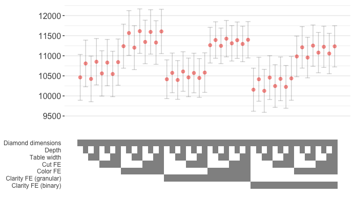

```r
stability_plot(data = diamonds,
                      lhs = 'price',
                      rhs = 'carat',
                      perm = perm_controls,
                      base = base_controls,
                      perm_fe = perm_fe_controls,
                      nonperm_fe = nonperm_fe_controls,
                      fe_always = F,
                      rel_height = 0.6)
```

## Instrumental variables

`starbility` also supports 2SLS estimation. To demonstrate, let’s try instrumenting `carat` with `x`,`y`, and `y`. This also means we will need to exclude `x`, `y`, and `z` from the controls.

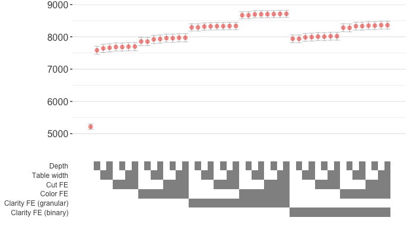

```r
instruments = 'x+y+z'

stability_plot(data = diamonds,
                      lhs = 'price',
                      rhs = 'carat',
                      iv = instruments,
                      perm = perm_controls,
                      perm_fe = perm_fe_controls,
                      nonperm_fe = nonperm_fe_controls,
                      fe_always = F,
                      rel_height = 0.6)
```

## Clustering and weights

Clustered standard errors and weights are supported using a straightforward syntax. In the example below, I generate some placeholder weights, then weight by these placeholders and cluster standard errors at the `cut` level.

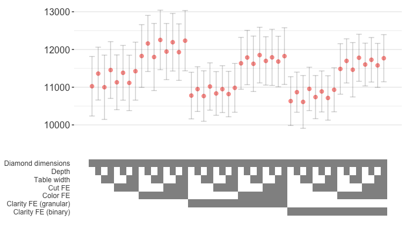

```r
diamonds$sample_weights = runif(n = nrow(diamonds))
stability_plot(data = diamonds,
                      lhs = 'price',
                      rhs = 'carat',
                      cluster = 'cut',
                      weights = 'sample_weights',
                      perm = perm_controls,
                      base = base_controls,
                      perm_fe = perm_fe_controls,
                      nonperm_fe = nonperm_fe_controls,
                      fe_always = F,
                      rel_height = 0.6)
```

## Adjusting standard errors, p-values, etc.

Let’s try an example where we divide the p-value by two (to simulate a one-tailed test) and we calculate 99% confidence intervals (instead of the default 95% confidence intervals.)

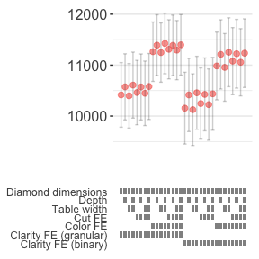

```r
starb_felm_custom = function(spec, data, rhs, ...) {
  spec = as.formula(spec)
  model = lfe::felm(spec, data=data) %>% broom::tidy()

  row = which(model$term==rhs)
  coef = model[row, 'estimate'] %>% as.numeric()
  se   = model[row, 'std.error'] %>% as.numeric()
  p    = model[row, 'p.value'] %>% as.numeric()

  z = qnorm(0.995)
  return(c(coef, p/2, coef+z*se, coef-z*se))
}

stability_plot(data = diamonds,
               lhs = 'price',
               rhs = 'carat',
               model = starb_felm_custom,
               perm = perm_controls,
               base = base_controls,
               perm_fe = perm_fe_controls,
               nonperm_fe = nonperm_fe_controls,
               fe_always = T,
               rel_height = 0.6)
```

## Aesthetics

Let’s now explore some options relating to plot aesthetics. The plots above have relatively few models, so let’s increase the number of models by specifying the dimensions as separate controls. Our model is estimated very precisely, so to make this example closer to a real-world application (in which coefficient estimates are often less precise), we’ll add randomly-generated noise to the dependent variable.

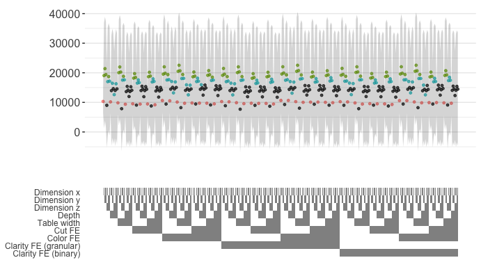

```r
diamonds$high_clarity = diamonds$clarity %in% c('VS1','VVS2','VVS1','IF')
diamonds$price = diamonds$price + rnorm(n = nrow(diamonds), sd = 12*sd(diamonds$price))

perm_controls = c(
  'Dimension x' = 'x',
  'Dimension y' = 'y',
  'Dimension z' = 'z',
  'Depth' = 'depth',
  'Table width' = 'table'
)
perm_fe_controls = c(
  'Cut FE' = 'cut',
  'Color FE' = 'color'
)
nonperm_fe_controls = c(
  'Clarity FE (granular)' = 'clarity',
  'Clarity FE (binary)' = 'high_clarity'
)

stability_plot(data = diamonds,
                      lhs = 'price',
                      rhs = 'carat',
                      error_geom = 'ribbon',
                      perm = perm_controls,
                      perm_fe = perm_fe_controls,
                      nonperm_fe = nonperm_fe_controls,
                      fe_always = F,
                      rel_height = 0.6)
```

Adding random noise also generated more variation in the p-values on our coefficient of interest. By default, `stabilityr` colors coefficients that are significant at $p<0.01$ red, coefficients significant at $p<0.05$ green, coefficients significant at $p<0.10$ blue, and coefficients that are not significant at $p<0.10$ black. Implementing custom breaks and custom colors is on my to-do list.

In previous plots, there were spaces between the markers indicating the presence of controls. This tends to look untidy when estimating many models, so by default, these spaces are eliminated when we estimate more than 40 models. However, if we wish, we can increase the spacing by setting `control_spacing<1`.

This type of plot is of course completely unhelpful if we’re interested in the coefficient value for a *given* set of controls. However, it can be helpful if we’re interested in giving our reader a general sense of how coefficient magnitudes evolve over different sets of controls.

### Sorting

By default, models are displayed in an order based on the ordering of controls. To instead display models by coefficient values, we can use the `sort` argument. `sort = asc` and `sort = desc` sort coefficient values in ascending and descending order, respectively. If we want to preserve the order of `nonperm_fe` groups but sort coefficient values within these groups, we can use `sort = asc-by-fe` and `sort = desc-by-fe`.

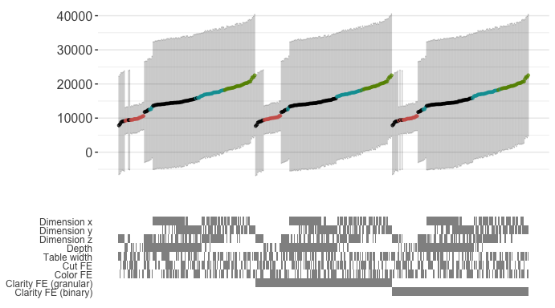

```r
stability_plot(data = diamonds,
                      lhs = 'price',
                      rhs = 'carat',
                      perm = perm_controls,
                      perm_fe = perm_fe_controls,
                      nonperm_fe = nonperm_fe_controls,
                      fe_always = F,
                      rel_height = 0.6,
                      sort = 'asc-by-fe')
```

This is useful in some contexts (e.g. to visualize the total range of the coefficient across all combinations of controls), but I generally prefer to keep the default ordering.

### Error geoms

Error bars can look a little cluttered. We can alternatively display confidence intervals using a ribbon with `error_geom = 'ribbon'`. This tends to be preferable when (1) we are using `sort` (or coefficients are already very stable) and (2) when we have a lot of models. We can also omit confidence intervals entirely with `error_geom = 'none'`.

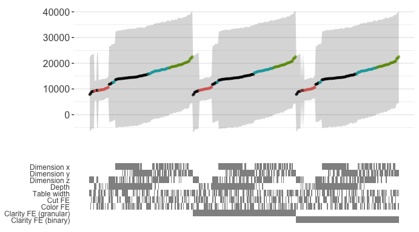

```r
stability_plot(data = diamonds,
                      lhs = 'price',
                      rhs = 'carat',
                      perm = perm_controls,
                      perm_fe = perm_fe_controls,
                      nonperm_fe = nonperm_fe_controls,
                      fe_always = F,
                      error_geom = 'ribbon',
                      rel_height = 0.6,
                      sort = 'asc-by-fe')
```

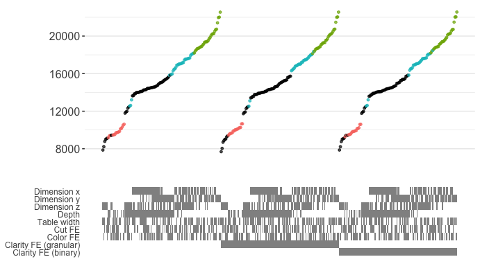

```r
stability_plot(data = diamonds,
                      lhs = 'price',
                      rhs = 'carat',
                      perm = perm_controls,
                      perm_fe = perm_fe_controls,
                      nonperm_fe = nonperm_fe_controls,
                      fe_always = F,
                      error_geom = 'none',
                      rel_height = 0.6,
                      sort = 'asc-by-fe')
```

### Control geoms

By default, `geom_rect` is used to indicate the presence of controls. `geom_rect` is a good choice when estimating many models, since blocks of continuous rectangles look more neat, but `geom_circle` can be a good alternative when we have fewer models. Some manual edits using `rel_height` and `control_spacing` are generally required.

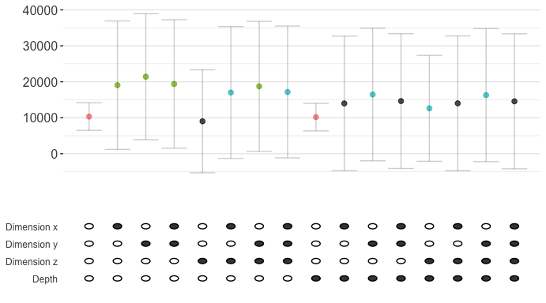

```r
stability_plot(data = diamonds,
                      lhs = 'price',
                      rhs = 'carat',
                      perm = perm_controls[1:4],
                      control_geom = 'circle',
                      fe_always = F,
                      rel_height = 0.6,
                      point_size = 2,
                      control_spacing = 0.3)
```

### Other options

A number of other aesthetic options are available:

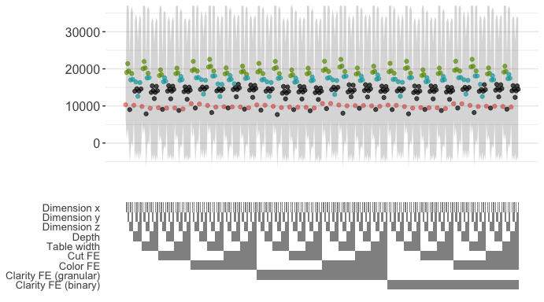

```r
stability_plot(data = diamonds,
                      lhs = 'price',
                      rhs = 'carat',
                      perm = perm_controls,
                      perm_fe = perm_fe_controls,
                      nonperm_fe = nonperm_fe_controls,
                      fe_always = F,
                      error_geom = 'ribbon',
                      rel_height = 0.7,
                      error_alpha = 0.2, # change alpha of the error geom
                      point_size = 1.5, # change the size of the coefficient points
                      control_text_size = 10, # change the size of the control labels
                      coef_ylim = c(-5000, 35000), # change the endpoints of the y-axis
                      trip_top = 3) # change the spacing between the two panels
```

## Further customization

By default, `stability_plot` returns a grid (generated by `cowplot`). We can instead return the bottom and top `ggplot2` panels individually using `run_to = 6` (more on this mysterious syntax in the advanced vignette). The advantage is that we can use standard `ggplot2` syntax to adapt the panels. In the example below, I reverse the $y$-axis, remove the minor horizontal rules, and add an annotation. We can then combine the plots using the `combine_plots` helper function.

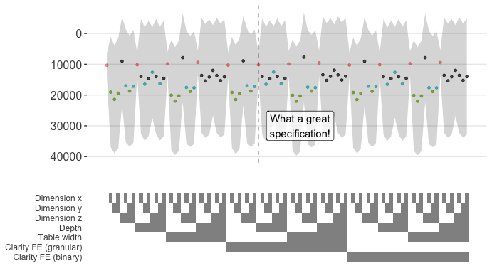

```r
plots = stability_plot(data = diamonds,
                              lhs = 'price',
                              rhs = 'carat',
                              perm = perm_controls,
                              error_geom = 'ribbon',
                              nonperm_fe = nonperm_fe_controls,
                              fe_always = F,
                              rel_height = 0.6,
                              run_to = 6)

replacement_coef_panel = plots[[1]] +
  scale_y_reverse() +
  theme(panel.grid.minor = element_blank()) +
  geom_vline(xintercept = 41, linetype = 'dashed', alpha = 0.4) +
  annotate(geom = 'label', x = 52, y = 30000, label = 'What a great\nspecification!', alpha = 0.75)

combine_plots(replacement_coef_panel,
              plots[[2]],
              rel_height = 0.6)
```

## Final notes

Comments, criticism, suggestions, pull requests, etc. are very much appreciated. Email: arao@g.harvard.edu. Thanks to David Yanagizawa-Drott for suggesting the structure of the plot and to Ross Mattheis and Eric Karsten for very helpful feedback.

If you’re ready to move on to more advanced features, the [advanced vignette](https://htmlpreview.github.io/?https://github.com/AakaashRao/starbility/blob/master/doc/starbility-advanced.html) discusses the following topics in greater depth:

1. The `starbility` pipeline
2. Estimate models that are not automatically supported in `starbility`. (Currently, the only function automatically supported is `felm`)
3. Manual `ggplot2` plotting
4. Combine multiple models in a single plot

Thanks for reading!